# Superstore: SQL ilə Satış və Mənfəət Analizi

Azer Azizov

01 noy 2026

## Setup

```r
library(data.table)
library(dplyr)
library(ggplot2)
library(readr)
library(readxl)
library(DT)
library(plotly)
library(DBI)
library(RSQLite)
library(knitr)
df=read.csv("Sample - Superstore.csv", fileEncoding = "latin1")
```

## Sütun adlarını dəyişimi

```r
names(df) <- c("row_id","order_id","order_date","ship_date","ship_mode",
               "customer_id","customer_name","segment","country","city",
               "state","postal_code","region","product_id","category",
               "sub_category","product_name","sales","quantity",
               "discount","profit")
```

## Tarix sütunun dəyişmək

```r
df$order_date <- format(as.Date(df$order_date, format = "%m/%d/%Y"), "%Y-%m-%d")
df$ship_date  <- format(as.Date(df$ship_date,  format = "%m/%d/%Y"), "%Y-%m-%d")
```

## Postal kodu mətn formatına çevirmek

```r
df$postal_code <- as.character(df$postal_code)
```

## Bazaya qoşulma

```r
con=dbConnect(SQLite(), "superstore.db")

dbExecute(con, "DROP TABLE IF EXISTS orders")
```

```
## [1] 0
```

```r
dbExecute(con, "
CREATE TABLE orders (
    row_id        INTEGER,
    order_id      TEXT,
    order_date    DATE,
    ship_date     DATE,
    ship_mode     TEXT,
    customer_id   TEXT,
    customer_name TEXT,
    segment       TEXT,
    country       TEXT,
    city          TEXT,
    state         TEXT,
    postal_code   TEXT,
    region        TEXT,
    product_id    TEXT,
    category      TEXT,
    sub_category  TEXT,
    product_name  TEXT,
    sales         NUMERIC,
    quantity      INTEGER,
    discount      NUMERIC,
    profit        NUMERIC
)")
```

```
## [1] 0
```

```r
#datani elave etmek
dbAppendTable(con, "orders", df)
```

```
## [1] 9994
```

## Task 5: queries.sql faylını oxumaq və Q1 (cədvəlin profili)

```r
sql_text <- paste(readLines("queries.sql"), collapse = "\n")
parts <- trimws(strsplit(sql_text, ";")[[1]])
parts <- parts[parts != ""]

get_q <- function(n) {
  idx <- grep(paste0("^-- Q", n, ":"), parts)
  dbGetQuery(con, parts[idx])
}

fm <- function(x) format(round(x, 2), big.mark = ",", nsmall = 0)

q1 <- get_q(1)
kable(q1)
```

| row_count | distinct_customers | distinct_products | min_order_date | max_order_date |
| --- | --- | --- | --- | --- |
| 9994 | 793 | 1862 | 2014-01-03 | 2017-12-30 |

## Task 6: Q2 (NULL sayı) və Q3 (dublikatlar)

```r
q2 <- get_q(2)

kable(data.frame(column = names(q2), null_count = unlist(q2[1, ])), row.names = FALSE)
```

| column | null_count |
| --- | --- |
| row_id_nulls | 0 |
| order_id_nulls | 0 |
| order_date_nulls | 0 |
| ship_date_nulls | 0 |
| ship_mode_nulls | 0 |
| customer_id_nulls | 0 |
| customer_name_nulls | 0 |
| segment_nulls | 0 |
| country_nulls | 0 |
| city_nulls | 0 |
| state_nulls | 0 |
| postal_code_nulls | 0 |
| region_nulls | 0 |
| product_id_nulls | 0 |
| category_nulls | 0 |
| sub_category_nulls | 0 |
| product_name_nulls | 0 |
| sales_nulls | 0 |
| quantity_nulls | 0 |
| discount_nulls | 0 |
| profit_nulls | 0 |

```r
q3 <- get_q(3)
cat("Dublikat order line sayı:", nrow(q3), "\n")
```

```
## Dublikat order line sayı: 8
```

```r
kable(head(q3, 10))
```

| order_id | product_id | cnt |
| --- | --- | --- |
| CA-2015-103135 | OFF-BI-10000069 | 2 |
| CA-2016-129714 | OFF-PA-10001970 | 2 |
| CA-2016-137043 | FUR-FU-10003664 | 2 |
| CA-2016-140571 | OFF-PA-10001954 | 2 |
| CA-2017-118017 | TEC-AC-10002006 | 2 |
| CA-2017-152912 | OFF-ST-10003208 | 2 |
| US-2014-150119 | FUR-CH-10002965 | 2 |
| US-2016-123750 | TEC-AC-10004659 | 2 |

## Task 7: Q4 (Ship Mode üzrə orta çatdırılma müddəti)

```r
q4 <- get_q(4)
kable(q4)
```

| ship_mode | avg_days_to_ship |
| --- | --- |
| Same Day | 0.04 |
| First Class | 2.18 |
| Second Class | 3.24 |
| Standard Class | 5.01 |

## Task 8: Q5 (Region, Category, Sub-Category) və Q6 (Top 5 / Bottom 5)

```r
q5 <- get_q(5)
cat("Q5 sətir sayı:", nrow(q5), "(ən zərərli 15 kombinasiya göstərilir)\n")
```

```
## Q5 sətir sayı: 68 (ən zərərli 15 kombinasiya göstərilir)
```

```r
kable(head(q5, 15))
```

| region | category | sub_category | total_sales | total_profit | profit_margin |
| --- | --- | --- | --- | --- | --- |
| East | Furniture | Tables | 39139.81 | -11025.38 | -0.2817 |
| South | Furniture | Tables | 43916.19 | -4623.06 | -0.1053 |
| Central | Furniture | Furnishings | 15254.37 | -3906.22 | -0.2561 |
| Central | Furniture | Tables | 39154.97 | -3559.65 | -0.0909 |
| Central | Office Supplies | Appliances | 23582.03 | -2638.62 | -0.1119 |
| Central | Furniture | Bookcases | 24157.18 | -1997.90 | -0.0827 |
| West | Furniture | Bookcases | 36004.12 | -1646.51 | -0.0457 |
| Central | Technology | Machines | 26797.38 | -1486.07 | -0.0555 |
| South | Technology | Machines | 53890.96 | -1438.89 | -0.0267 |
| East | Furniture | Bookcases | 43819.33 | -1167.63 | -0.0266 |
| East | Office Supplies | Supplies | 10760.12 | -1155.14 | -0.1074 |
| Central | Office Supplies | Binders | 56923.28 | -1043.64 | -0.0183 |
| Central | Office Supplies | Supplies | 9467.37 | -661.89 | -0.0699 |
| West | Technology | Machines | 42444.12 | -618.93 | -0.0146 |
| South | Office Supplies | Supplies | 8318.93 | 1.88 | 0.0002 |

```r
q6 <- get_q(6)
kable(q6)
```

| sub_category | total_profit | group_label |
| --- | --- | --- |
| Copiers | 55617.82 | Top 5 |
| Phones | 44515.73 | Top 5 |
| Accessories | 41936.64 | Top 5 |
| Paper | 34053.57 | Top 5 |
| Binders | 30221.76 | Top 5 |
| Machines | 3384.76 | Bottom 5 |
| Fasteners | 949.52 | Bottom 5 |
| Supplies | -1189.10 | Bottom 5 |
| Bookcases | -3472.56 | Bottom 5 |
| Tables | -17725.48 | Bottom 5 |

## Task 9: Q7 (Endirim bantları)

```r
q7 <- get_q(7)
kable(q7)
```

| discount_band | order_count | avg_profit | total_profit |
| --- | --- | --- | --- |
| 0% | 2644 | 66.90 | 320987.60 |
| 1-20% | 2507 | 26.50 | 100785.47 |
| 21-40% | 400 | -77.86 | -35817.47 |
| 41%+ | 737 | -106.71 | -99558.59 |

## Task 10: Q8 (İllik satış və YoY)

```r
q8 <- get_q(8)
kable(q8)
```

| year | total_sales | yoy_abs | yoy_pct |
| --- | --- | --- | --- |
| 2014 | 484247.5 | NA | NA |
| 2015 | 470532.5 | -13714.99 | -2.83 |
| 2016 | 609205.6 | 138673.09 | 29.47 |
| 2017 | 733215.3 | 124009.66 | 20.36 |

## Task 11: Q9 (Mənfi profitli sub-category-lər) və Q10 (Top 10 müştəri)

```r
q9 <- get_q(9)
kable(q9)
```

| sub_category | total_profit | total_sales | revenue_share_pct |
| --- | --- | --- | --- |
| Tables | -17725.48 | 206965.53 | 9.01 |
| Bookcases | -3472.56 | 114880.00 | 5.00 |
| Supplies | -1189.10 | 46673.54 | 2.03 |

```r
q10 <- get_q(10)
kable(q10)
```

| customer_id | customer_name | lifetime_profit | order_count | avg_order_value |
| --- | --- | --- | --- | --- |
| TC-20980 | Tamara Chand | 8981.32 | 5 | 3810.44 |
| RB-19360 | Raymond Buch | 6976.10 | 6 | 2519.56 |
| SC-20095 | Sanjit Chand | 5757.41 | 9 | 1571.37 |
| HL-15040 | Hunter Lopez | 5622.43 | 6 | 2145.55 |
| AB-10105 | Adrian Barton | 5444.81 | 10 | 1447.36 |
| TA-21385 | Tom Ashbrook | 4703.79 | 4 | 3648.91 |
| CM-12385 | Christopher Martinez | 3899.89 | 4 | 2238.51 |
| KD-16495 | Keith Dawkins | 3038.63 | 12 | 681.77 |
| AR-10540 | Andy Reiter | 2884.62 | 6 | 1101.41 |
| DR-12940 | Daniel Raglin | 2869.08 | 8 | 1043.86 |

## Task 12: Qrafik 1 - Sub-category üzrə profit (mənfilər fərqli rəngdə)

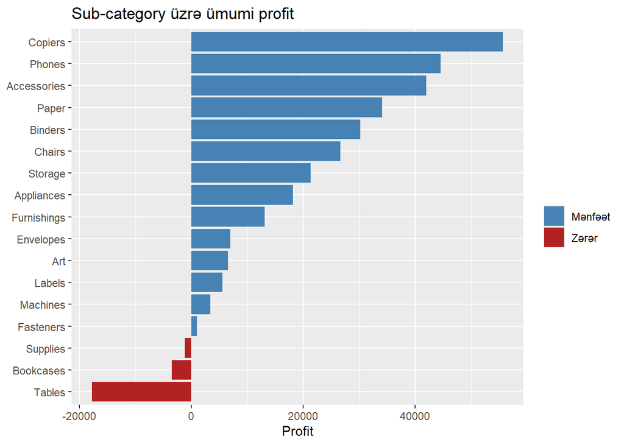

```r
q6b <- get_q("6b")
q6b$status <- ifelse(q6b$total_profit < 0, "Zərər", "Mənfəət")

ggplot(q6b, aes(x = reorder(sub_category, total_profit),
                y = total_profit,
                fill = status)) +
  geom_col() +
  coord_flip() +
  scale_fill_manual(values = c("Zərər" = "firebrick", "Mənfəət" = "steelblue"),
                    name = "") +
  labs(title = "Sub-category üzrə ümumi profit",
       x = NULL, y = "Profit")
```

## Task 13: Qrafik 2 - Endirim bandı üzrə orta profit

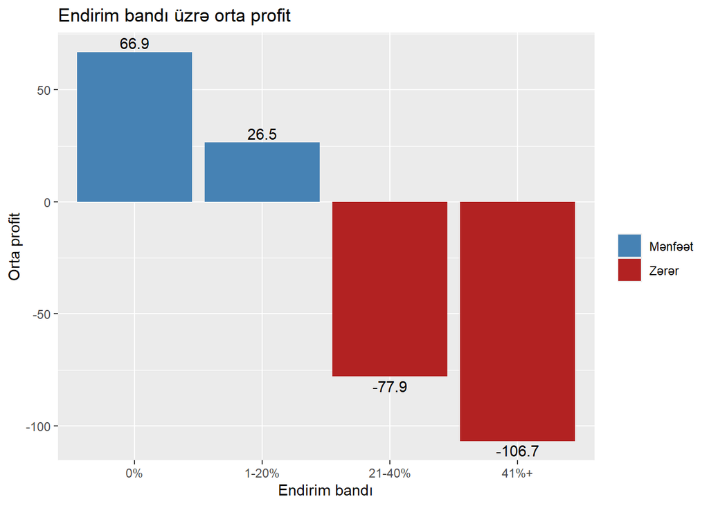

```r
q7$discount_band <- factor(q7$discount_band,
                           levels = c("0%", "1-20%", "21-40%", "41%+"))
q7$status <- ifelse(q7$avg_profit < 0, "Zərər", "Mənfəət")

ggplot(q7, aes(x = discount_band, y = avg_profit, fill = status)) +
  geom_col() +
  geom_text(aes(label = round(avg_profit, 1)),
            vjust = ifelse(q7$avg_profit < 0, 1.3, -0.3)) +
  scale_fill_manual(values = c("Zərər" = "firebrick", "Mənfəət" = "steelblue"),
                    name = "") +
  labs(title = "Endirim bandı üzrə orta profit",
       x = "Endirim bandı", y = "Orta profit")
```

## Task 14: Qrafik 3 - İllik satış trendi (YoY etiketləri ilə)

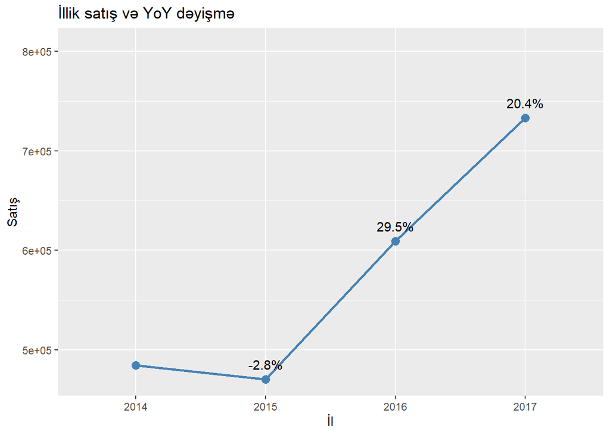

```r
q8$label <- ifelse(is.na(q8$yoy_pct), "", paste0(round(q8$yoy_pct, 1), "%"))

ggplot(q8, aes(x = year, y = total_sales, group = 1)) +
  geom_line(color = "steelblue", linewidth = 1) +
  geom_point(size = 3, color = "steelblue") +
  geom_text(aes(label = label), vjust = -1) +
  expand_limits(y = max(q8$total_sales) * 1.1) +
  labs(title = "İllik satış və YoY dəyişmə",
       x = "İl", y = "Satış")
```

## Task 15: 4 biznes insight-ı

Aşağıdakı rəqəmlər yuxarıdakı sorğu nəticələrindən avtomatik götürülür (R yalnız mətnə yerləşdirir, hesablama SQL-dədir).

**Insight 1 (Q9):** Zərərli sub-category-lər: Tables, Bookcases, Supplies. Onların birgə profiti -22,387.14, gəlirdəki payı isə 16.04%-dir. Yəni gəlirin bu hissəsi mənfəət gətirmir, əksinə itirir. Bu sub-category-lərdə qiymət və maya dəyərinə yenidən baxmaq profiti birbaşa artırar.

**Insight 2 (Q7):** `41%+` endirim bandında orta profit -106.71, ümumi profit -99,558.59-dir. `0%` bandında isə orta profit 66.9-dir. Böyük endirimlər zərər yaradır, buna görə endirim tavanı qoymaq tövsiyə olunur.

**Insight 3 (Q5):** Ən zərərli kombinasiya East regionunda Tables (Furniture) olub: profit -11,025.38, marja -28.17%. Problem bütün şirkətdə yox, konkret region və sub-category cütlüklərində cəmləşib. Bu cütlüklər üçün ayrıca qiymət və endirim siyasəti qurmaq lazımdır.

**Insight 4 (Q6 və Q6b):** Ən mənfəətli sub-category Copiers-dir (profit 55,617.82). Bu, bütün sub-category-lərin ümumi profitinin (286,397) təxminən 19.42%-ini təşkil edir. Mənfəət bir neçə sub-category-dən asılıdır, ona görə marketinq və stok investisiyasını ən yüksək marjalı məhsullara yönəltmək profiti artırar.

## Bonus 1: Region/Category üçün view və yığma cədvəl

```r
exec_q <- function(n) {
  idx <- grep(paste0("^-- Q", n, ":"), parts)
  dbExecute(con, parts[idx])
}

exec_q("11a")
```

```
## [1] 0
```

```r
exec_q("11b")
```

```
## [1] 0
```

```r
q11c <- get_q("11c")
cat("View-dan oxunan sətir sayı:", nrow(q11c), "\n")
```

```
## View-dan oxunan sətir sayı: 68
```

```r
kable(head(q11c, 10))
```

| region | category | sub_category | total_sales | total_profit | profit_margin |
| --- | --- | --- | --- | --- | --- |
| East | Furniture | Tables | 39139.81 | -11025.38 | -0.2817 |
| South | Furniture | Tables | 43916.19 | -4623.06 | -0.1053 |
| Central | Furniture | Furnishings | 15254.37 | -3906.22 | -0.2561 |
| Central | Furniture | Tables | 39154.97 | -3559.65 | -0.0909 |
| Central | Office Supplies | Appliances | 23582.03 | -2638.62 | -0.1119 |
| Central | Furniture | Bookcases | 24157.18 | -1997.90 | -0.0827 |
| West | Furniture | Bookcases | 36004.12 | -1646.51 | -0.0457 |
| Central | Technology | Machines | 26797.38 | -1486.07 | -0.0555 |
| South | Technology | Machines | 53890.96 | -1438.89 | -0.0267 |
| East | Furniture | Bookcases | 43819.33 | -1167.63 | -0.0266 |

```r
exec_q("11d")
```

```
## [1] 0
```

```r
exec_q("11e")
```

```
## [1] 0
```

```r
exec_q("11f")
```

```
## [1] 0
```

```r
dbGetQuery(con, "SELECT COUNT(*) AS summary_rows FROM region_category_summary")
```

```
##   summary_rows
## 1           68
```

## Bonus 2: Bir regionda mənfəətli, digərində zərərli sub-category-lər (Q12)

```r
q12 <- get_q(12)
kable(q12)
```

| sub_category | profitable_regions | losing_regions | profitable_in | losing_in |
| --- | --- | --- | --- | --- |
| Appliances | 3 | 1 | East, South, West | Central |
| Binders | 3 | 1 | East, South, West | Central |
| Bookcases | 1 | 3 | South | Central, East, West |
| Furnishings | 3 | 1 | East, South, West | Central |
| Machines | 1 | 3 | East | Central, South, West |
| Supplies | 2 | 2 | South, West | Central, East |
| Tables | 1 | 3 | West | Central, East, South |

## Bonus 3: İl daxilində aylıq yığılan (cumulative) satış (Q13)

```r
q13 <- get_q(13)
kable(head(q13, 12))
```

| year | month | monthly_sales | cumulative_sales |
| --- | --- | --- | --- |
| 2014 | 01 | 14236.90 | 14236.90 |
| 2014 | 02 | 4519.89 | 18756.79 |
| 2014 | 03 | 55691.01 | 74447.80 |
| 2014 | 04 | 28295.35 | 102743.14 |
| 2014 | 05 | 23648.29 | 126391.43 |
| 2014 | 06 | 34595.13 | 160986.56 |
| 2014 | 07 | 33946.39 | 194932.95 |
| 2014 | 08 | 27909.47 | 222842.42 |
| 2014 | 09 | 81777.35 | 304619.77 |
| 2014 | 10 | 31453.39 | 336073.16 |
| 2014 | 11 | 78628.72 | 414701.88 |
| 2014 | 12 | 69545.62 | 484247.50 |

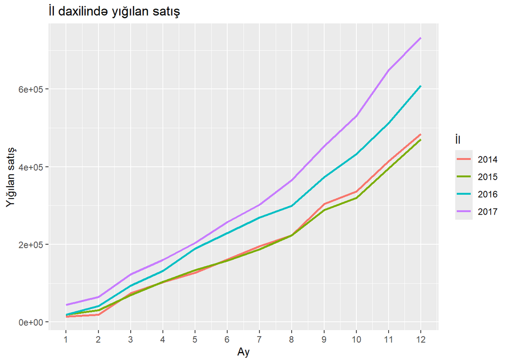

```r
ggplot(q13, aes(x = as.integer(month), y = cumulative_sales, color = year, group = year)) +
  geom_line(linewidth = 1) +
  scale_x_continuous(breaks = 1:12) +
  labs(title = "İl daxilində yığılan satış", x = "Ay", y = "Yığılan satış", color = "İl")
```

## Bonus 4: EXPLAIN QUERY PLAN (Q5 sorğusu)

```r
exec_q("14a")
```

```
## [1] 0
```

```r
cat("--- İndeksdən ƏVVƏL ---\n")
```

```
## --- İndeksdən ƏVVƏL ---
```

```r
print(get_q("14b")$detail)
```

```
## [1] "SCAN orders"                  "USE TEMP B-TREE FOR GROUP BY"
## [3] "USE TEMP B-TREE FOR ORDER BY"
```

```r
exec_q("14c")
```

```
## [1] 0
```

```r
cat("\n--- İndeksdən SONRA ---\n")
```

```
##
## --- İndeksdən SONRA ---
```

```r
print(get_q("14d")$detail)
```

```
## [1] "SCAN orders USING COVERING INDEX idx_orders_region_cat_sub"
## [2] "USE TEMP B-TREE FOR ORDER BY"
```

## Bonus 5: SQL nəticəsinin R ilə yoxlanması (Q5)

```r
check <- df %>%
  group_by(region, category, sub_category) %>%
  summarise(r_sales = round(sum(sales), 2),
            r_profit = round(sum(profit), 2),
            r_margin = round(sum(profit) / sum(sales), 4),
            .groups = "drop")

cmp <- merge(q5, check, by = c("region", "category", "sub_category"))

cat("SQL sətir sayı:", nrow(q5), "| R sətir sayı:", nrow(check), "| birləşən:", nrow(cmp), "\n")
```

```
## SQL sətir sayı: 68 | R sətir sayı: 68 | birləşən: 68
```

```r
cat("Maksimum sales fərqi:  ", max(abs(cmp$total_sales  - cmp$r_sales)), "\n")
```

```
## Maksimum sales fərqi:   0
```

```r
cat("Maksimum profit fərqi: ", max(abs(cmp$total_profit - cmp$r_profit)), "\n")
```

```
## Maksimum profit fərqi:  0
```

```r
cat("Maksimum marja fərqi:  ", max(abs(cmp$profit_margin - cmp$r_margin)), "\n")
```

```
## Maksimum marja fərqi:   0
```

```r
cat("Nəticələr eynidir:",
    nrow(q5) == nrow(check) && nrow(cmp) == nrow(q5) &&
    max(abs(cmp$total_sales - cmp$r_sales)) < 0.011 &&
    max(abs(cmp$total_profit - cmp$r_profit)) < 0.011 &&
    max(abs(cmp$profit_margin - cmp$r_margin)) < 0.00011, "\n")
```

```
## Nəticələr eynidir: TRUE
```